# q4

## 1.

For this quiz we will be using several R packages. R package versions change over time, the right answers have been checked using the following versions of the packages.

AppliedPredictiveModeling: v1.1.6 caret: v6.0.47 ElemStatLearn: v2012.04-0 pgmm: v1.1 rpart: v4.1.8 gbm: v2.1 lubridate: v1.3.3 forecast: v5.6 e1071: v1.6.4

If you aren’t using these versions of the packages, your answers may not exactly match the right answer, but hopefully should be close.

Load the vowel.train and vowel.test data sets:

```r
library(ElemStatLearn)
library(caret)
library(randomForest)
data(vowel.train)
data(vowel.test)

# Set the variable y to be a factor variable in both the training and test set. Then set the seed to 33833. Fit (1) a random forest predictor relating the factor variable y to the remaining variables and (2) a boosted predictor using the "gbm" method. Fit these both with the train() command in the caret package.

vowel.train$y <- as.factor(vowel.train$y)
vowel.test$y <- as.factor(vowel.test$y)
set.seed(33833)
#fit_rf <- train(y ~., method = "rf", data = vowel.train) #bad performance
fit_rf <- randomForest(y ~., data = vowel.train)
fit_bst <- train(y ~., method = "gbm", data = vowel.train, verbose = F)

#fit_rf$finalModel
#fit_bst$finalModel

# use the models to predict the results on the testing set individually
pred_rf <- predict(fit_rf, vowel.test)
pred_bst <- predict(fit_bst, vowel.test)

# Calculate accuracy (# agreements/total)
acc <- function (x, z) {
    len <- length(z)
    agree <- 0
    total <- 0
    for (i in 1:len){
        if (x[i] == z[i])
            agree <- agree + 1
        total <- total +1
        }
    return(agree/total)
    }

acc_rf <- acc(pred_rf, vowel.test$y)
acc_bst <- acc(pred_bst, vowel.test$y)
# option 2
confusionMatrix(pred_rf, vowel.test$y)$overall[1]
```

```
##  Accuracy
## 0.5800866
```

```r
confusionMatrix(pred_bst, vowel.test$y)$overall[1]
```

```
##  Accuracy
## 0.5324675
```

```r
# Calculate accuracy for the samples where the two methods aggree
len <- length(vowel.test$y)
identic <- 0 # both rf and bst predict the same value
agree <- 0 # both agree
total <- 0
    for (i in 1:len){
        if (pred_rf[i] == pred_bst[i]) {
            identic <- identic + 1
            if (pred_rf[i] == vowel.test$y[i])
                agree <- agree + 1
            }
        total <- total +1
        }
acc_both <- agree/identic
acc_both
```

```
## [1] 0.6292835
```

```r
# # new dataset for model ensemble.
# pred_train_rf <- predict(fit_rf, vowel.train)
# pred_train_bst <- predict(fit_bst, vowel.train)
# train_comb <- data.frame(pred_train_rf, pred_train_bst, y = vowel.train$y)
# test_comb <- data.frame(pred_rf, pred_bst)
#
# #and where there is aggreement. As we only have train-test, we train on train dataset
# fit_comb <- train(y ~ ., method = "mva", train_comb)
# #predict with model ensemble
# #Warning message: 'newdata' had 462 rows but variables found have 528 rows
# pred_comb <- predict(fit_comb, test_comb)
#
# comb_res <- data.frame(pred_rf, pred_bst, pred_comb, y = vowel.test$y)
# View(comb_res)
#
# # What are the accuracies for the two approaches on the test data set?
# # Accuracies for each of the models
# rf_accu <- sqrt(sum((as.integer(pred_rf) - as.integer(vowel.test$y))^2))
# bst_accu <- sqrt(sum((as.integer(pred_bst) - as.integer(vowel.test$y))^2))
#
# confusionMatrix(pred_comb, vowel.test$y)$overall[1]
```

What are the accuracies for the two approaches on the test data set? What is the accuracy among the test set samples where the two methods agree?

RF Accuracy = 0.9987 GBM Accuracy = 0.5152 Agreement Accuracy = 0.9985

RF Accuracy = 0.3233 GBM Accuracy = 0.8371 Agreement Accuracy = 0.9983

## 2.

Load the Alzheimer’s data using the following commands

```r
library(caret)
library(gbm)
library(pander)
library(xtable)
library(randomForest)
set.seed(3433)
library(AppliedPredictiveModeling)
data(AlzheimerDisease)
adData = data.frame(diagnosis,predictors)
inTrain = createDataPartition(adData$diagnosis, p = 3/4)[[1]]
training = adData[ inTrain,]
testing = adData[-inTrain,]

#Set the seed to 62433 and predict diagnosis with all the other variables using a random forest ("rf"), boosted trees ("gbm") and linear discriminant analysis ("lda") model. Stack the predictions together using random forests ("rf").
set.seed(62433)
#fit_rf <- train(diagnosis ~., method = "rf", data = training) #bad performance
fit_rf <- randomForest(diagnosis ~., data = training)
fit_gbm <- train(diagnosis ~., method = "gbm", data = training, verbose = F)
fit_lda <- train(diagnosis ~., method = "lda", data = training, verbose = F)
pred_test_rf <- predict(fit_rf, testing)
pred_test_gbm <- predict(fit_gbm, testing)
pred_test_lda <- predict(fit_lda, testing)

#create aggregate dataset
pred_train_rf <- predict(fit_rf, training)
pred_train_gbm <- predict(fit_gbm, training)
pred_train_lda <- predict(fit_lda, training)

train_comb <- data.frame(pred_train_rf, pred_train_gbm, pred_train_lda, diagnosis = training$diagnosis)
test_comb <- data.frame(pred_test_rf, pred_test_gbm, pred_test_lda, diagnosis = testing$diagnosis)

# train stacked model
# fit_comb <- train(diagnosis ~., method = "rf", data = test_comb) # bad performance
fit_comb <- randomForest(diagnosis ~., data = test_comb)
pred_comb <- predict(fit_comb, test_comb)

# check accuracy
acc_rf <- confusionMatrix(pred_test_rf, testing$diagnosis)$overall[1]
acc_rf
```

```
## Accuracy
## 0.804878
```

```r
acc_gbm <- confusionMatrix(pred_test_gbm, testing$diagnosis)$overall[1]
acc_gbm
```

```
## Accuracy
## 0.804878
```

```r
acc_lda <- confusionMatrix(pred_test_lda, testing$diagnosis)$overall[1]
acc_lda
```

```
##  Accuracy
## 0.7682927
```

```r
acc_comb <- confusionMatrix(pred_comb, testing$diagnosis)$overall[1]
acc_comb
```

```
##  Accuracy
## 0.8170732
```

```r
result <- c(acc_rf, acc_gbm, acc_lda, acc_comb)
#colnames(result) <- c("acc_rf", "acc_gbm", "acc_lda", "acc_comb")
result
```

```
##  Accuracy  Accuracy  Accuracy  Accuracy
## 0.8048780 0.8048780 0.7682927 0.8170732
```

```r
table <- xtable(matrix(result, ncol = 4, dimnames =list(NULL, c("acc_rf", "acc_gbm", "acc_lda", "acc_comb"))))
pander(table)
```

| acc_rf | acc_gbm | acc_lda | acc_comb |
| --- | --- | --- | --- |
| 0.8049 | 0.8049 | 0.7683 | 0.8171 |

```r
# using randomForest
```

What is the resulting accuracy on the test set? Is it better or worse than each of the individual predictions?

Stacked Accuracy: 0.76 is better than random forests and boosting, but not lda. –> Stacked Accuracy: 0.80 is better than all three other methods –> Stacked Accuracy: 0.80 is better than random forests and lda and the same as boosting. Stacked Accuracy: 0.76 is better than lda but not random forests or boosting.

## 3.

Load the concrete data with the commands:

```r
set.seed(3523)
library(AppliedPredictiveModeling)
library(dplyr)
library(elasticnet)
data(concrete)
inTrain = createDataPartition(concrete$CompressiveStrength, p = 3/4)[[1]]
training = concrete[ inTrain,]
testing = concrete[-inTrain,]

#Set the seed to 233 and fit a lasso model to predict Compressive Strength.
set.seed(233)
fit_lasso <- enet(as.matrix(select(concrete, -CompressiveStrength)), concrete$CompressiveStrength, lambda =0, trace = TRUE)
```

```
## LARS-EN Step 1 :  Variable 1     added
## LARS-EN Step 2 :  Variable 5     added
## LARS-EN Step 3 :  Variable 8     added
## LARS-EN Step 4 :  Variable 2     added
## LARS-EN Step 5 :  Variable 4     added
## LARS-EN Step 6 :  Variable 7     added
## LARS-EN Step 7 :  Variable 3     added
## LARS-EN Step 7 :  Variable 7     dropped
## LARS-EN Step 9 :  Variable 6     added
## LARS-EN Step 10 :     Variable 7     added
```

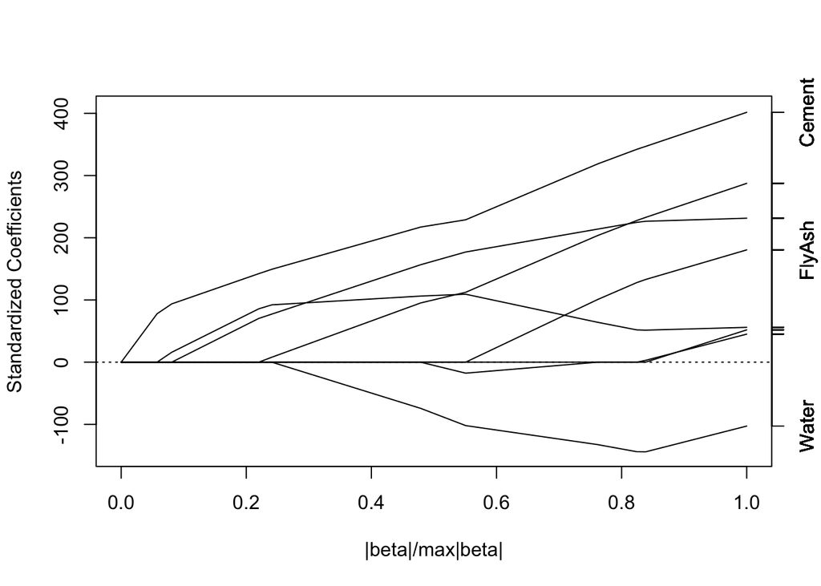

```r
plot.enet(fit_lasso)
```

Which variable is the last coefficient to be set to zero as the penalty increases? (Hint: it may be useful to look up ?plot.enet).

CoarseAggregate FineAggregate –> Cement BlastFurnaceSlag

## 4.

Load the data on the number of visitors to the instructors blog from here: https://d396qusza40orc.cloudfront.net/predmachlearn/gaData.csv Using the commands:

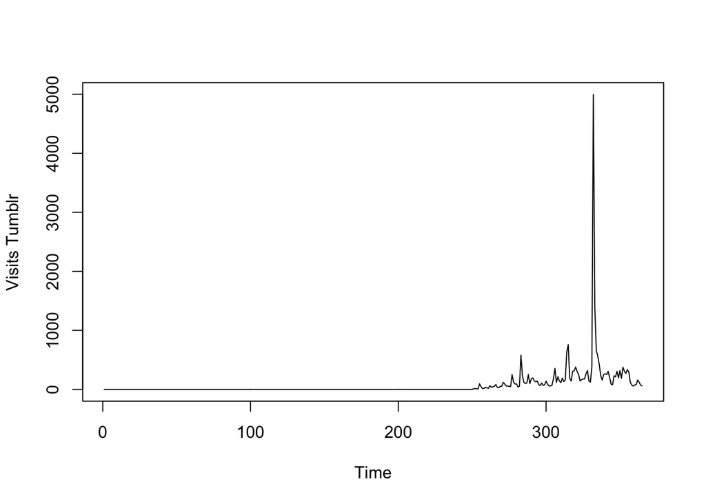

```r
library(lubridate) # For year() function below
library(forecast)

filename = "./gaData.csv"
file_url <- "https://d396qusza40orc.cloudfront.net/predmachlearn/gaData.csv"
if (!file.exists(filename)) {
        print("INFO: csv file not found")
        ### Getting the dataset, and unzipping the files
        download.file(file_url, filename, method = "curl")
        date_downloaded <- date()
    }

#opening the data
dat = read.csv(filename)

training = dat[year(dat$date) < 2012,]
testing = dat[(year(dat$date)) > 2011,]
tstrain = ts(training$visitsTumblr)
tstest <- ts(testing$visitsTumblr)
plot(tstrain, ylab = "Visits Tumblr")
```

```r
#Fit a model using the bats() function in the forecast package to the training time series. Then forecast this model for the remaining time points.
fit <- bats(tstrain)
tspred <- forecast(fit,level = c(95), h =length(tstest))


agree <- 0
total <- 0
for (i in 1 : length(tstest)) {
    if (tstest[i] > tspred$lower[i] & tstest[i] < tspred$upper[i])
        agree <- agree + 1
    total <- total + 1
}

result <- agree/total
result
```

```
## [1] 0.9617021
```

```r
accuracy(tspred, ts(testing$visitsTumblr, start = length(tstrain) + 1))
```

```
##                     ME     RMSE       MAE      MPE     MAPE      MASE
## Training set  10.39787 258.7813  40.22707     -Inf      Inf 0.8437138
## Test set     185.20149 301.2620 205.87807 26.06409 40.76475 4.3180420
##                   ACF1 Theil's U
## Training set 0.0121040        NA
## Test set     0.4751213  1.092536
```

```r
accuracy
```

[output not shown]

For how many of the testing points is the true value within the 95% prediction interval bounds?

93% 94% –> 96% 98%

## 5.

Load the concrete data with the commands:

```r
set.seed(3523)
library(caret)
library(AppliedPredictiveModeling)
library(dplyr)
library(e1071)
data(concrete)
inTrain = createDataPartition(concrete$CompressiveStrength, p = 3/4)[[1]]
training = concrete[ inTrain,]
testing = concrete[-inTrain,]
#Set the seed to 325 and fit a support vector machine using the e1071 package to predict Compressive Strength using the default settings.
set.seed(325)
fit_svm <- svm(y = training$CompressiveStrength, x = select(training, -CompressiveStrength))
pred_svm <- predict(fit_svm, newdata = select(testing, -CompressiveStrength))
sqrt(mean((pred_svm - testing$CompressiveStrength)^2))
```

```
## [1] 6.715009
```

Predict on the testing set. What is the RMSE?

–> 6.72 107.44 6.93 35.59